# Data Chek ver2 last biz day version

This is to use IvyDB pricedata and another factor DB to tou ji dao ba. This file is to check the basic data integrity. It is reading from the root directory for the simplicity now.

The bp is aligned with the last biz day of a month so an inner_join on Date would be sufficient.

### *Step.1 Read IVYDB mapping and ZY DB to inner_join on cusip.*

```r
mapping=readRDS("securitylist.rds") # the IVYDB mapping
IVYmapping<-mapping %>%
  select(SecurityID,CUSIP,Ticker)

print(head(IVYmapping))
```

```
##   SecurityID    CUSIP Ticker
## 1       5001 00078110 ZZZZ
## 2       5003 00103810 AFAP
## 3       5006 00244810 AWCSE
## 4       5007 61757710 MRCBF
## 5       5010 00504110 AACZE
## 6       5013 05541310 ZZZZ
```

```r
ZYmapping=read.csv("cusip.csv",stringsAsFactors = F, header = F) #ZY's mapping, no header, will add by myself.

ZYmapping<-ZYmapping %>%
  rename(Date=V1,BBG=V2,CUSIP=V5,Name=V6) %>%
  select(Date,BBG,CUSIP,Name) # rename the columns, and only keep those columns
print(head(ZYmapping))
```

```
##                  Date     BBG     CUSIP           Name
## 1 2020-12-31 00:00:00 AAPL UW 037833100          APPLE
## 2 2020-12-31 00:00:00 MSFT UW 594918104 MICROSOFT CORP
## 3 2020-12-31 00:00:00 AMZN UW 023135106     AMAZON.COM
## 4 2020-12-31 00:00:00 TSLA UW 88160R101          TESLA
## 5 2020-12-31 00:00:00   FB UW 30303M102     FACEBOOK A
## 6 2020-12-31 00:00:00 GOOG UW 02079K107     ALPHABET C
```

We will do an inner_join and check on some tickers and the dimension of the DB. AAPL CUSIP==037833100 in ZYDB, ==03783310 in IVYDB, so we try to remove the last character in ZYDB? In the last print we will see 5 IDs from ZYDB is missing from IVY. 这里就是有些CUSIP的缺失问题，先暂时手动该来匹配了。 记住IVY cusip只有8位，这个是一定要处理的，不然数据就对不齐了

```r
mess=paste("ZY DB # of stocks",nrow(ZYmapping))
print(mess)
```

```
## [1] "ZY DB # of stocks 621"
```

```r
mess=paste("IVY DB # of stocks",nrow(IVYmapping))
print(mess)
```

```
## [1] "IVY DB # of stocks 21085"
```

```r
ZYmapping<-ZYmapping %>%
  mutate(CUSIP=str_sub(CUSIP,start=1,end=-2)) # remove the last digit

finalmapping<-IVYmapping %>%
  inner_join(ZYmapping,by="CUSIP")

mess=paste("megedDB # of stocks",nrow(finalmapping))
print(mess)
```

```
## [1] "megedDB # of stocks 616"
```

```r
missingID=ZYmapping %>%
  filter(!CUSIP %in% finalmapping$CUSIP)

print(missingID)
```

```
##                  Date     BBG    CUSIP                     Name
## 1 2020-12-31 00:00:00   GE UN 36960410      GENERAL ELECTRIC CO
## 2 2020-12-31 00:00:00 MRVL UW G5876H10 MARVELL TECHNOLOGY GROUP
## 3 2020-12-31 00:00:00  STX UW G7945M10       SEAGATE TECHNOLOGY
## 4 2020-12-31 00:00:00  IAC UW 44891N10 IAC/INTERACTIVECORP(NEW)
## 5 2020-12-31 00:00:00 LUMN UN 15670010       LUMEN TECHNOLOGIES
```

```r
# Something fucking weird is that GE's cusip is 36960430 in IVY? STX is G7997R10
```

I can directly modify my IVYDB for those 5 tickers

```r
IVYmapping2<-IVYmapping %>%
  mutate(CUSIP=ifelse(CUSIP=="36960430","36960410",CUSIP)) %>%
  mutate(CUSIP=ifelse(CUSIP=="57387410","G5876H10",CUSIP)) %>%
  mutate(CUSIP=ifelse(CUSIP=="G7997R10","G7945M10",CUSIP)) %>%
  mutate(CUSIP=ifelse(CUSIP=="44891N20","44891N10",CUSIP)) %>%
  mutate(CUSIP=ifelse(CUSIP=="55024110","15670010",CUSIP))

finalmapping<-IVYmapping2 %>%
  inner_join(ZYmapping,by="CUSIP") %>%
  mutate(Date=as.Date(Date)) %>%
  select(-Date) # remove the Date column for nowm, may need it later on for point in time study

mess=paste("megedDB # of stocks",nrow(finalmapping))
print(mess)
```

```
## [1] "megedDB # of stocks 621"
```

```r
print(head(finalmapping))
```

```
##   SecurityID    CUSIP Ticker     BBG                 Name
## 1     100892 00105510 AFL     AFL UN                AFLAC
## 2     100900 00130H10 AES     AES UN             AES CORP
## 3     100906 74340W10 PLD     PLD UN             PROLOGIS
## 4     100958 80360710 SRPT   SRPT UW SAREPTA THERAPEUTICS
## 5     100972 00282410 ABT     ABT UN  ABBOTT LABORATORIES
## 6     100978 00365410 ABMD   ABMD UW              ABIOMED
```

### *Step.2 Check PB factor*

1. Get the PB factor 所有的PB都是月底才有一个数值 然后日期不是交易日，所以需要我处理一下找出月份。

```r
# get the PB factors
PBfactor<-read.csv("bp.csv",stringsAsFactors = F,header = F)

colnames(PBfactor)=c("Date","CUSIP","Factor_name","bp")
PBfactor<-PBfactor %>%
  mutate(Date=as.Date(Date),Y=year(Date),M=month(Date)) %>%
  mutate(CUSIP=str_sub(CUSIP,start=1,end=-2)) # CUSIP treatment

print(head(PBfactor))
```

```
##         Date    CUSIP Factor_name        bp    Y M
## 1 2007-05-31 00088630          bp 0.2781827 2007 5
## 2 2007-05-31 00105510          bp 0.3283182 2007 5
## 3 2007-05-31 00130H10          bp 0.1350981 2007 5
## 4 2007-05-31 00163T10          bp 0.6084470 2007 5
## 5 2007-05-31 00206R10          bp 0.4432026 2007 5
## 6 2007-05-31 00282410          bp 0.1509988 2007 5
```

2. Get the IVYDB price data and inner_join with the mapping info at first. The pricedata was already na filled with previous valid data until delisting. Can check that proces again together. Will put into more details about the columns later. Price:unadjusted price. Cumret:adjusted for both split and dividend. splitAdj:split, check AAPL for an example.tempSPX:the SPX index value on that date.

```r
# using feather data now. Can switch to fst for faster data load if working with R only
pricedata<-rio::import("JQCpricedata.feather")
print(head(pricedata))
```

```
##         Date SecurityID Price        Volume TotalReturn splitAdj
## 1 1996-01-02       5001 7.625 9.337841e-320    0.000000        1
## 2 1996-01-03       5001 8.500 2.519735e-320    0.114754        1
## 3 1996-01-04       5001 8.500 4.940656e-322    0.000000        1
## 4 1996-01-05       5001 8.000 7.312172e-320   -0.058824        1
## 5 1996-01-08       5001 8.000 9.881313e-322    0.000000        1
## 6 1996-01-09       5001 7.250 2.282583e-319   -0.093750        1
##   SharesOutstanding Adj     cap Adj_prices    Cumret Adj_prices2     ratio
## 1              5052   1 38521.5      7.625 1.0000000    7.625000 1.0000000
## 2              5052   1 42942.0      8.500 1.1147540    8.499999 0.9999999
## 3              5052   1 42942.0      8.500 1.1147540    8.499999 0.9999999
## 4              5052   1 40416.0      8.000 1.0491797    7.999995 0.9999994
## 5              5052   1 40416.0      8.000 1.0491797    7.999995 0.9999994
## 6              5052   1 36627.0      7.250 0.9508191    7.249996 0.9999994
##   tempSPX size_rank
## 1  620.73      2820
## 2  621.32      2770
## 3  617.70      2785
## 4  616.71      2861
## 5  618.46      2874
## 6  609.45      2945
```

```r
newpricedata<-pricedata %>%
  inner_join(finalmapping,by="SecurityID") # about 1/10 of the all stock data, make sense ha
print(head(newpricedata))
```

```
##         Date SecurityID  Price        Volume TotalReturn splitAdj
## 1 1996-01-02     100892 44.375 7.238062e-319    0.000000        1
## 2 1996-01-03     100892 45.875 1.080522e-318    0.033803        1
## 3 1996-01-04     100892 45.375 8.354650e-319   -0.010899        1
## 4 1996-01-05     100892 45.250 8.735081e-319   -0.002755        1
## 5 1996-01-08     100892 45.500 7.855644e-320    0.005525        1
## 6 1996-01-09     100892 45.250 5.681755e-319   -0.005495        1
##   SharesOutstanding Adj     cap Adj_prices   Cumret Adj_prices2    ratio
## 1             94753   1 4204664   2.354632 1.000000    44.37500 18.84583
## 2             94753   1 4346794   2.434225 1.033803    45.87501 18.84583
## 3             94753   1 4299417   2.407694 1.022536    45.37502 18.84584
## 4             94753   1 4287573   2.401062 1.019718    45.25001 18.84583
## 5             94753   1 4311262   2.414327 1.025352    45.50001 18.84584
## 6             94753   1 4287573   2.401062 1.019718    45.24999 18.84583
##   tempSPX size_rank    CUSIP Ticker    BBG  Name
## 1  620.73       223 00105510 AFL    AFL UN AFLAC
## 2  621.32       215 00105510 AFL    AFL UN AFLAC
## 3  617.70       216 00105510 AFL    AFL UN AFLAC
## 4  616.71       218 00105510 AFL    AFL UN AFLAC
## 5  618.46       215 00105510 AFL    AFL UN AFLAC
## 6  609.45       216 00105510 AFL    AFL UN AFLAC
```

3. Combine with the PB info. There could be 2 ways to deal with it. Inner_join or left_join and fill na with previous value. <1> Inner_join style on Date

```r
#only select the price within the fundamental factor data range. can be flexible later
minDate=min(PBfactor$Date)
maxDate=max(PBfactor$Date)

EOMdata<-newpricedata %>%
  select(Date,SecurityID,CUSIP,BBG,size_rank,Price,Cumret,tempSPX) %>%
  filter(Date>=minDate,Date<=maxDate) %>%
  mutate(M=month(Date),Y=year(Date)) %>%
  group_by(SecurityID,M,Y) %>%
  arrange(Date) %>%
  filter(row_number()==n()) %>%
  ungroup()# select the last observation in a month for each ID

print(head(EOMdata))
```

```
## # A tibble: 6 x 10
##   Date       SecurityID CUSIP   BBG    size_rank Price Cumret tempSPX     M
##   <date>          <dbl> <chr>   <chr>      <dbl> <dbl>  <dbl>   <dbl> <int>
## 1 2007-05-31     100892 001055~ AFL UN       158 52.9   7.91    1531.     5
## 2 2007-05-31     100900 00130H~ AES UN       273 23.7   4.13    1531.     5
## 3 2007-05-31     100906 74340W~ PLD UN       576 57.8   4.15    1531.     5
## 4 2007-05-31     100958 803607~ SRPT ~      3962  3.05  0.469   1531.     5
## 5 2007-05-31     100972 002824~ ABT UN        35 56.3   3.64    1531.     5
## 6 2007-05-31     100978 003654~ ABMD ~      3019 11.2   1.55    1531.     5
## # ... with 1 more variable: Y <int>
```

```r
### now inner_join by Month and Year for each ID, ver1 is the old style
finalver1<-EOMdata %>%
  inner_join(PBfactor,by=c("CUSIP","Y","M"))

final<-newpricedata %>%
  select(Date,SecurityID,CUSIP,BBG,size_rank,Price,Cumret,tempSPX) %>%
  filter(Date>=minDate,Date<=maxDate) %>%
  inner_join(PBfactor,by=c("CUSIP","Date"))


## final的数据比finalver1要少点 少的是起始月份不同的问题 我们可以对比一下看每个月都有啥不同，完全一样了
## 所以就用简单的final就可以了

check1<-finalver1 %>%
  group_by(Y,M) %>%
  summarise(n_ob_EOM=n())
check2<-final %>%
  group_by(Y,M) %>%
  summarise(n_ob_final=n())
compare=check1 %>%
  inner_join(check2,by=c("Y","M")) %>%
  mutate(obs_diff=n_ob_EOM-n_ob_final)
```

<2>Left_join style. Will be needed for daily factor models

4. Use the “biased” PB factor to evaluate the factor performance.In my codes “y” is the return for the next period. date.y is from PBdata date.x is from pricedata. We will use decile rank for now and we can use Z-score weighted neutral style

```r
factordata<-final %>%
  group_by(SecurityID) %>%
  arrange(Date) %>%
  mutate(y=lead(Cumret)/Cumret) %>%
  na.omit()

divs=10 # deciles.
factorret<-factordata %>%
  group_by(M,Y) %>%
  mutate(decile=ntile(bp,divs)) %>%
  group_by(M,Y,decile) %>%
  summarise(decileret=mean(y,na.rm=T)-1,Date=min(Date))
```

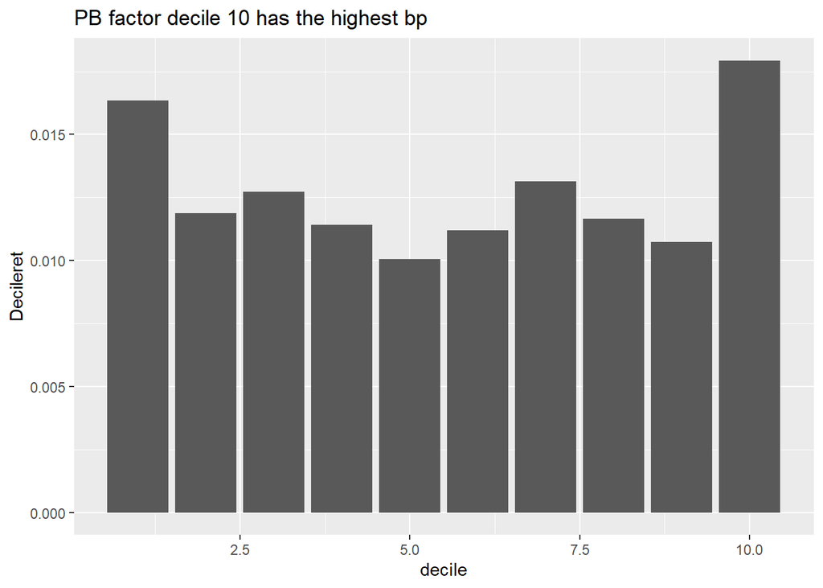

```r
factorret %>%
    group_by(decile) %>%
    summarise(Decileret=mean(decileret,na.rm=T)) %>%
    ggplot(aes(x=decile,y=Decileret)) + geom_bar(stat = "identity") + ggtitle("PB factor decile 10 has the highest bp")
```

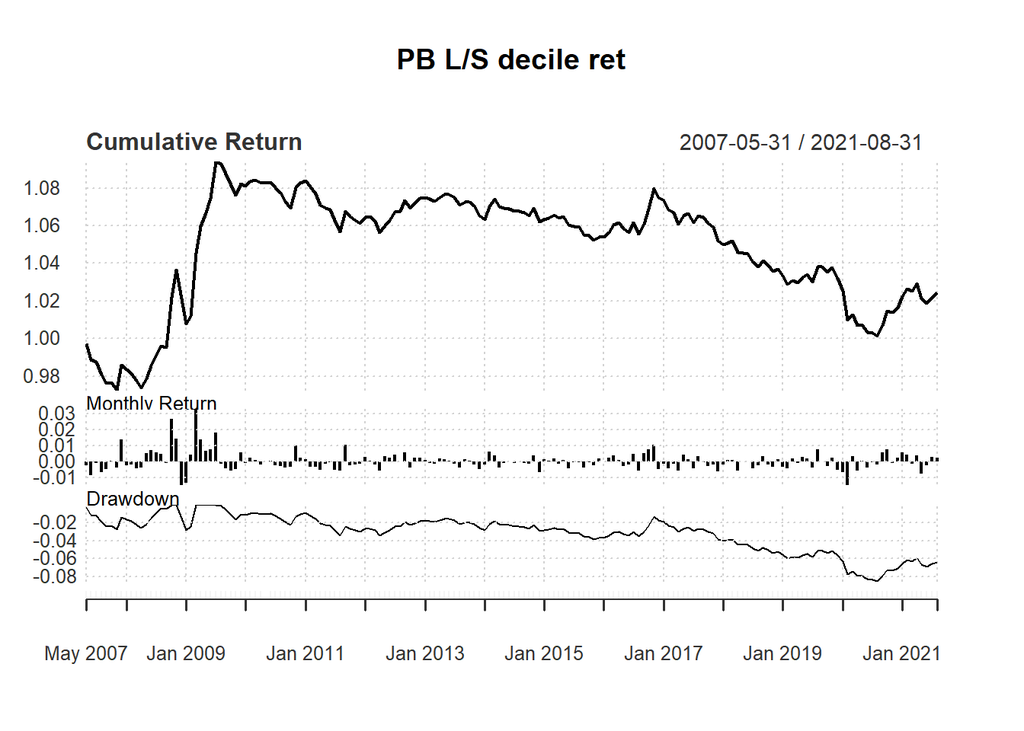

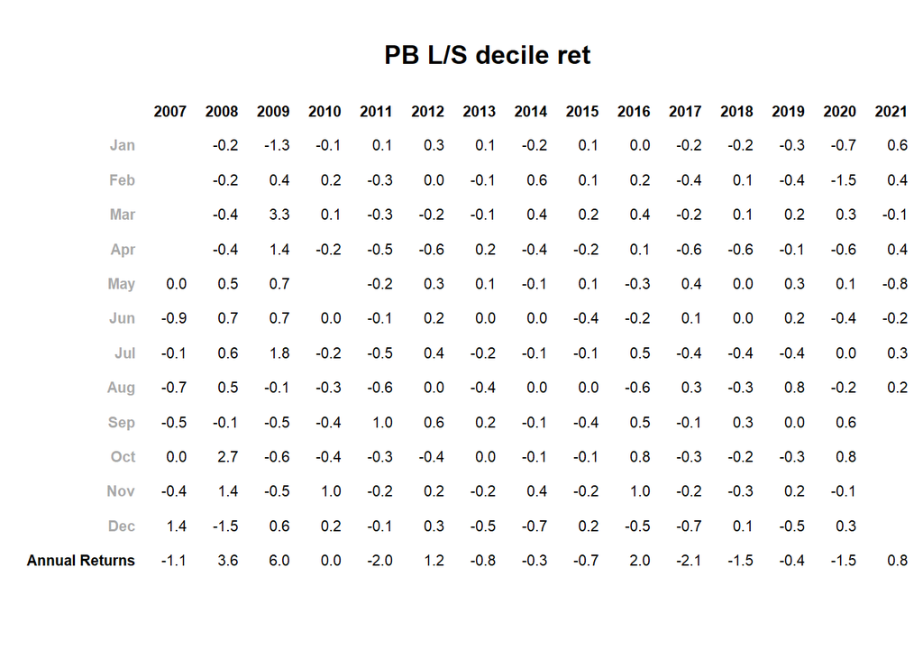

```
##                           PB L/S decile ret
## Annualized Return                0.00170000
## Annualized Std Dev               0.02020000
## Annualized Sharpe (Rf=0%)        0.08380000
## Max DD                           0.08491263
## Calmar Ratio                     0.01994400
## # of trades                    171.00000000
```

```r
LSret<-factorret %>%
  group_by(M,Y) %>%
  arrange(decile) %>%
  mutate(weight = case_when(
      decile==10 ~ 1,
      decile==1 ~ -1,
      TRUE     ~ 0
    ))

strat=LSret %>%
  group_by(Date) %>%
  summarise(portret=mean(weight*decileret))

strats=xts(strat$portret,order.by = strat$Date)
source("C:/jiaqifiles/R code/Persupportfunc.r")
mess=("PB L/S decile ret")
PnLreport(strats,info = mess,freq=12)
```